# Project - Go Term Enrichment Analysis

Julia Lapucha, Astghik Sarukhanyan, Caroline Forsythe

2024-05-22

Analysis workflow based on Bioconductor package ClusterProfiler [ClusterProfiler-Workflow-Link](https://yulab-smu.top/biomedical-knowledge-mining-book/clusterprofiler-go.html)

```r
pacman::p_load(tidyverse, ggplot2, DESeq2, data.table, vsn, apeglm, biomaRt, ggfortify, BiocManager, ComplexHeatmap, clusterProfiler, DOSE, enrichplot)
library("RColorBrewer")
library(GOstats); library(GO.db); library(org.Hs.eg.db); library(ReactomePA)
dir <- "C:/Users/astghik/Documents/Uni/Master/DATA SCIENCE/Project/"
load(paste0(dir, "ANALYSIS/GoTermEnrichment/goTermEnrichment.RData"))
```

```r
count.matrix <- read.delim(paste0(dir, "DATA/rnaseq/GSE134056_countdata_rnaseq.txt"),
                   header = TRUE)
head(count.matrix)
```

|  | N_0026 | N_0035 | N_0036 | N_0039 | N_0042 | N_0045 | N_0046 | N_0054 | N_0055 | N_0057 | N_0058 | N_0060 | W_001 | W_002 | W_004 | W_006 | W_007 | W_008 | W_010 | W_011 | W_012 | W_015 | W_017 | W_018 | W_023 | W_028 | W_030 | W_033 | W_035 | … |
| --- | --- | --- | --- | --- | --- | --- | --- | --- | --- | --- | --- | --- | --- | --- | --- | --- | --- | --- | --- | --- | --- | --- | --- | --- | --- | --- | --- | --- | --- | --- |
| ENSG00000000005 | 2 | 0 | 0 | 0 | 0 | 0 | 2 | 0 | 0 | 0 | 0 | 0 | 0 | 0 | 0 | 0 | 0 | 0 | 1 | 0 | 0 | 1 | 0 | 2 | 0 | 0 | 0 | 1 | 0 | … |
| ENSG00000000419 | 4 | 4 | 5 | 7 | 11 | 14 | 1 | 13 | 8 | 14 | 7 | 10 | 0 | 11 | 8 | 2 | 6 | 3 | 8 | 4 | 8 | 11 | 2 | 10 | 0 | 10 | 8 | 0 | 7 | … |
| ENSG00000000457 | 241 | 153 | 341 | 120 | 322 | 235 | 214 | 257 | 122 | 295 | 271 | 246 | 237 | 276 | 211 | 233 | 208 | 131 | 192 | 240 | 225 | 299 | 119 | 313 | 186 | 259 | 229 | 241 | 232 | … |
| ENSG00000000460 | 241 | 411 | 393 | 381 | 360 | 394 | 292 | 269 | 311 | 357 | 290 | 495 | 340 | 434 | 433 | 424 | 472 | 329 | 416 | 397 | 441 | 409 | 352 | 478 | 206 | 386 | 390 | 439 | 498 | … |
| ENSG00000000938 | 0 | 0 | 0 | 0 | 1 | 0 | 0 | 0 | 0 | 1 | 0 | 0 | 1 | 3 | 0 | 0 | 0 | 0 | 0 | 0 | 0 | 2 | 0 | 0 | 0 | 1 | 1 | 0 | 3 | … |
| ENSG00000000971 | 0 | 0 | 1 | 0 | 0 | 0 | 0 | 2 | 0 | 0 | 0 | 0 | 0 | 0 | 0 | 0 | 0 | 0 | 0 | 0 | 0 | 0 | 0 | 0 | 0 | 0 | 0 | 0 | 0 | … |

```r
count.meth <- read.csv(file = paste0(dir, "ANALYSIS/MBDseq/annotedMethylationCounts_allsamples.csv"), header = T) %>% as.data.frame() %>% column_to_rownames(var = "X")
```

Load data from Differential Expression Analysis:

```r
sig_005 = readRDS(file = paste0(dir, "ANALYSIS/DEGs/Output/sig_005.rds"))
head(sig_005)
```

|  | ensembl_gene_id | baseMean | log2FoldChange | lfcSE | pvalue | padj | external_gene_name | description | gene_exp |
| --- | --- | --- | --- | --- | --- | --- | --- | --- | --- |
| 1 | ENSG00000040531 | 245.6647 | -0.62241629 | 0.2219716 | 0.0002130697 | 0.02922896 | CTNS | cystinosin, lysosomal cystine transporter [Source:HGNC Symbol;Acc:HGNC:2518] | down |
| 2 | ENSG00000066230 | 313.3952 | -0.84926326 | 0.3408092 | 0.0003836496 | 0.03882818 | SLC9A3 | solute carrier family 9 member A3 [Source:HGNC Symbol;Acc:HGNC:11073] | down |
| 3 | ENSG00000077157 | 196.1929 | 0.04446617 | 0.1214844 | 0.0001418887 | 0.02323457 | PPP1R12B | protein phosphatase 1 regulatory subunit 12B [Source:HGNC Symbol;Acc:HGNC:7619] | up |
| 4 | ENSG00000092098 | 188.0548 | -0.56510545 | 0.1997210 | 0.0001959776 | 0.02827483 | RNF31 | ring finger protein 31 [Source:HGNC Symbol;Acc:HGNC:16031] | down |
| 5 | ENSG00000099901 | 193.7538 | -0.34417506 | 0.1255530 | 0.0004597645 | 0.04186885 | RANBP1 | RAN binding protein 1 [Source:HGNC Symbol;Acc:HGNC:9847] | down |
| 6 | ENSG00000100242 | 494.6828 | -0.39287755 | 0.1455830 | 0.0004371348 | 0.04186885 | SUN2 | Sad1 and UNC84 domain containing 2 [Source:HGNC Symbol;Acc:HGNC:14210] | down |

Load data from Differential Methylation Analysis:

```r
sig_DMR = readRDS(file = paste0(dir, "ANALYSIS/MBDseq/Output/sig_DMR.rds"))
head(sig_DMR)
```

|  | logFC | logCPM | LR | PValue | FDR | ensembl_gene_id | chromosome_name | start_position | end_position | external_gene_name | gene_biotype |
| --- | --- | --- | --- | --- | --- | --- | --- | --- | --- | --- | --- |
| 1 | -0.3639171 | 4.478243 | 24.47535 | 7.526662e-07 | 0.03180515 | ENSG00000226243 | 20 | 44466564 | 44466842 | RPL37AP1 | processed_pseudogene |
| 2 | -0.3462134 | 6.022108 | 22.65568 | 1.937869e-06 | 0.03180515 | ENSG00000127578 | 16 | 629239 | 634117 | WFIKKN1 | protein_coding |
| 3 | 1.0122447 | 2.352801 | 22.33323 | 2.292062e-06 | 0.03180515 | ENSG00000100083 | 22 | 37608474 | 37633564 | GGA1 | protein_coding |
| 4 | 0.6452756 | 2.810993 | 21.42070 | 3.687675e-06 | 0.03180515 | ENSG00000244130 | 3 | 72006774 | 72006975 | UBE2Q2P9 | processed_pseudogene |
| 5 | 0.7782453 | 2.270451 | 21.15433 | 4.237420e-06 | 0.03180515 | ENSG00000222636 | 7 | 101058299 | 101058567 | RN7SKP54 | misc_RNA |
| 6 | -0.3456904 | 5.251105 | 21.00694 | 4.576220e-06 | 0.03180515 | ENSG00000130731 | 16 | 634427 | 636366 | METTL26 | protein_coding |

Is there any overlap in Ensembl Ids between significant DMRs and DEGs?

```r
intersect(sig_005$ensembl_gene_id, sig_DMR$ensembl_gene_id)
```

```
## character(0)
```

# GO TERMS

## Differential Expression Analysis

```r
ggo <- groupGO(gene = sig_005$ensembl_gene_id,
               OrgDb    = org.Hs.eg.db,
               keyType = "ENSEMBL",
               ont      = "BP",
               level    = 4,
               readable = TRUE)

head(ggo)
```

|  | ID | Description | Count | GeneRatio | geneID |
| --- | --- | --- | --- | --- | --- |
| GO:0000747 | GO:0000747 | conjugation with cellular fusion | 0 | 0/100 |  |
| GO:0000748 | GO:0000748 | conjugation with mutual genetic exchange | 0 | 0/100 |  |
| GO:0000909 | GO:0000909 | sporocarp development involved in sexual reproduction | 0 | 0/100 |  |
| GO:0007276 | GO:0007276 | gamete generation | 3 | 3/100 | TSNAXIP1/KLC3/B4GALNT1 |
| GO:0007618 | GO:0007618 | mating | 0 | 0/100 |  |
| GO:0009566 | GO:0009566 | fertilization | 0 | 0/100 |  |

```r
ggoM <- groupGO(gene = sig_DMR$ensembl_gene_id,
               OrgDb    = org.Hs.eg.db,
               keyType = "ENSEMBL",
               ont      = "BP",
               level    = 4,
               readable = TRUE)
```

# GO over-representation analysis

```r
ego <- enrichGO(gene          = sig_005$ensembl_gene_id,
                universe      = rownames(count.matrix),
                keyType = "ENSEMBL",
                OrgDb         = org.Hs.eg.db,
                ont           = "BP",
                pAdjustMethod = "BH",
                pvalueCutoff  = 0.5,
                qvalueCutoff  = 0.5,
        readable      = TRUE)
head(ego)
```

|  | ID | Description | GeneRatio | BgRatio | pvalue | p.adjust | qvalue | geneID | Count |
| --- | --- | --- | --- | --- | --- | --- | --- | --- | --- |
| GO:0000101 | GO:0000101 | sulfur amino acid transport | 2/46 | 13/18192 | 0.0004793184 | 0.1561283 | 0.1440679 | CTNS/MFSD12 | 2 |
| GO:0043455 | GO:0043455 | regulation of secondary metabolic process | 2/46 | 16/18192 | 0.0007338581 | 0.1561283 | 0.1440679 | CTNS/MFSD12 | 2 |
| GO:0048021 | GO:0048021 | regulation of melanin biosynthetic process | 2/46 | 16/18192 | 0.0007338581 | 0.1561283 | 0.1440679 | CTNS/MFSD12 | 2 |
| GO:1900376 | GO:1900376 | regulation of secondary metabolite biosynthetic process | 2/46 | 16/18192 | 0.0007338581 | 0.1561283 | 0.1440679 | CTNS/MFSD12 | 2 |
| GO:1904263 | GO:1904263 | positive regulation of TORC1 signaling | 2/46 | 24/18192 | 0.0016662820 | 0.2243320 | 0.2070031 | CTNS/PIH1D1 | 2 |
| GO:0042438 | GO:0042438 | melanin biosynthetic process | 2/46 | 25/18192 | 0.0018082657 | 0.2243320 | 0.2070031 | CTNS/MFSD12 | 2 |

```r
ego@result %>% dplyr::filter(p.adjust < 0.05)
```

| ID | Description | GeneRatio | BgRatio | pvalue | p.adjust | qvalue | geneID | Count |
| --- | --- | --- | --- | --- | --- | --- | --- | --- |

```r
egoM <- enrichGO(gene          = sig_DMR$ensembl_gene_id,
                universe      = rownames(count.meth),
                keyType = "ENSEMBL",
                OrgDb         = org.Hs.eg.db,
                ont           = "BP",
                pAdjustMethod = "BH",
                pvalueCutoff  = 0.5,
                qvalueCutoff  = 0.5,
        readable      = TRUE)
```

# VISUALIZATION

[ALSO LOOK HERE](https://yulab-smu.top/biomedical-knowledge-mining-book/enrichplot.html?q=dotpl#dot-plot)

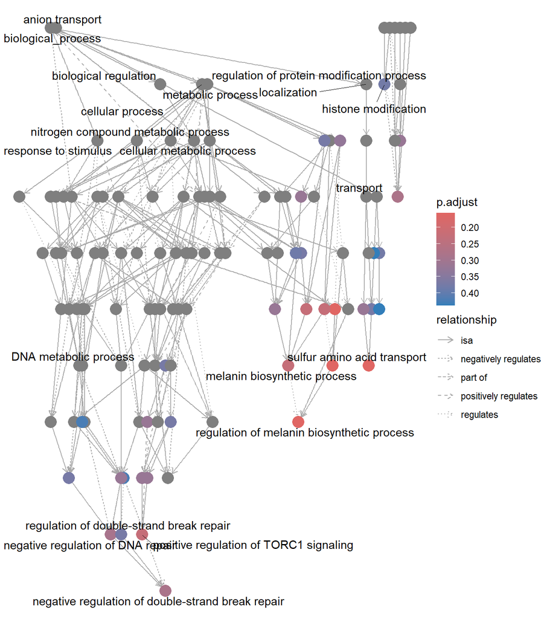

```r
goplot(ego)
```

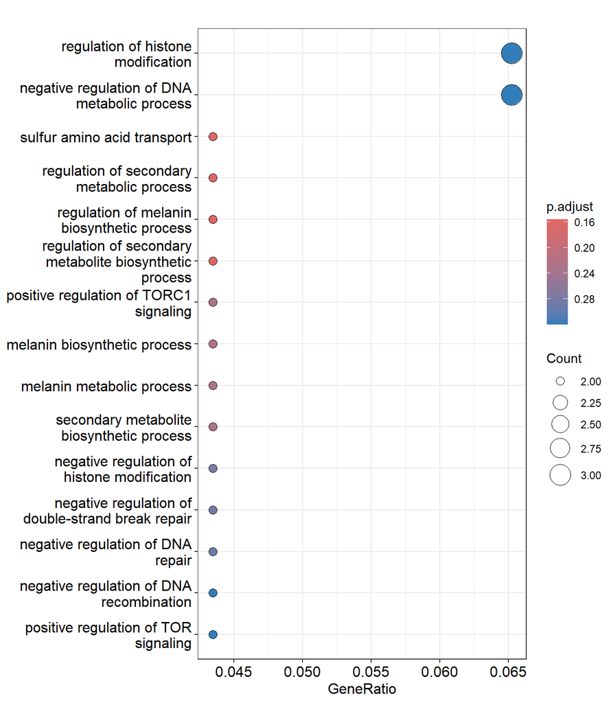

```r
dotplot(ego, showCategory = 15)
```

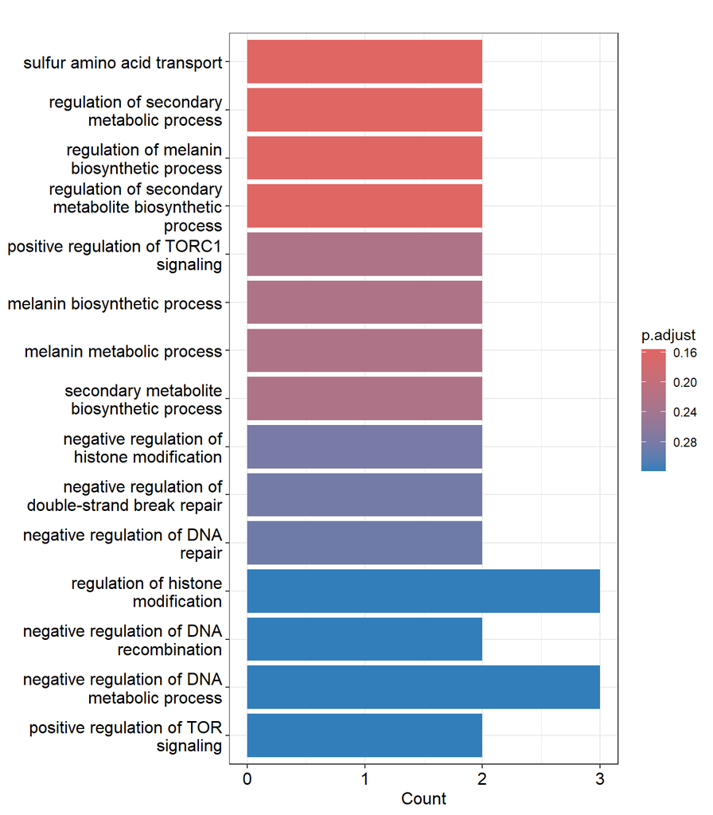

```r
barplot(ego, showCategory=15)
```

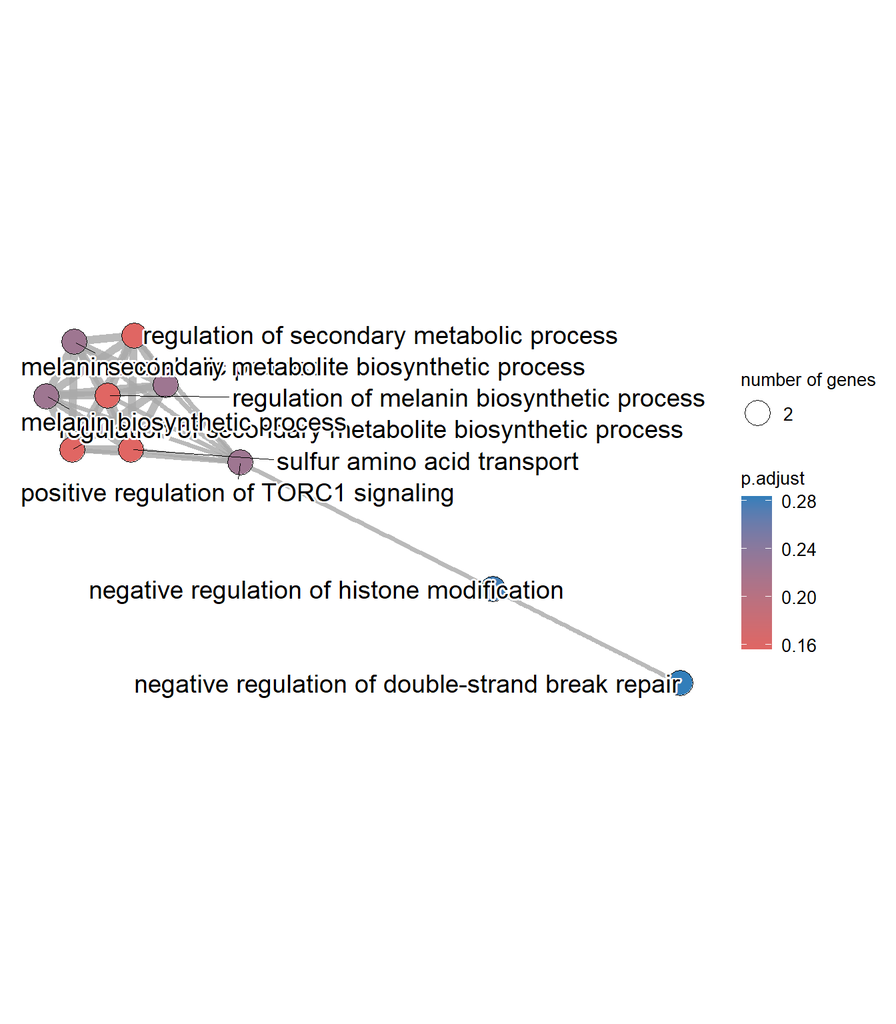

```r
x<-pairwise_termsim(ego)
emapplot(x, showCategory = 10)
```

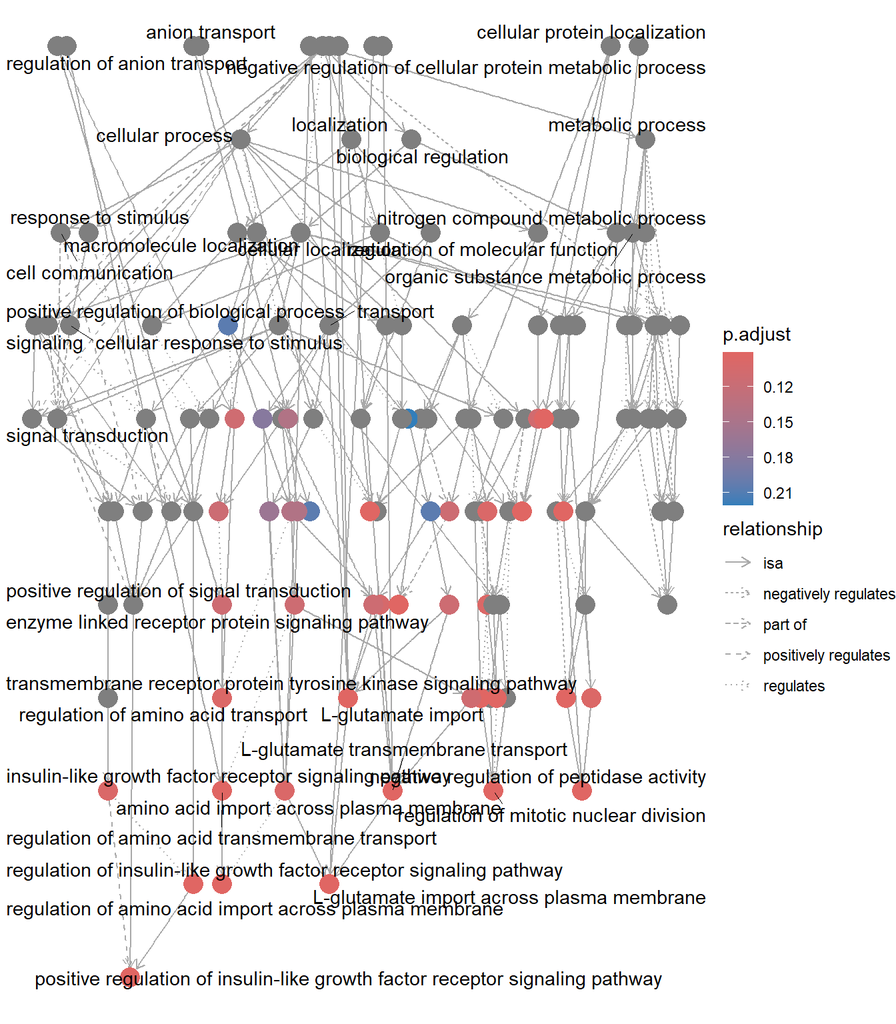

```r
goplot(egoM)
```

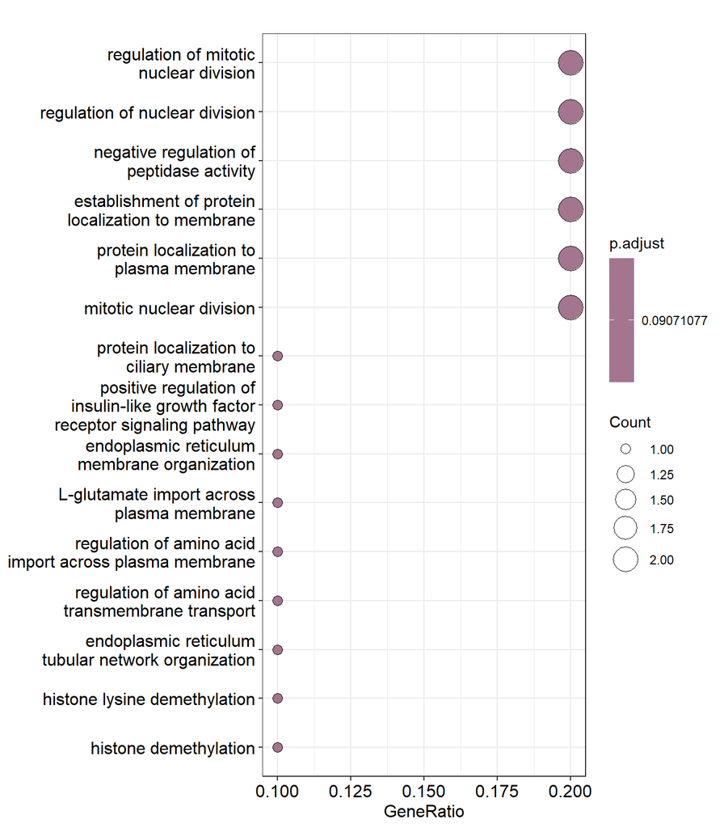

```r
dotplot(egoM, showCategory = 15)
```

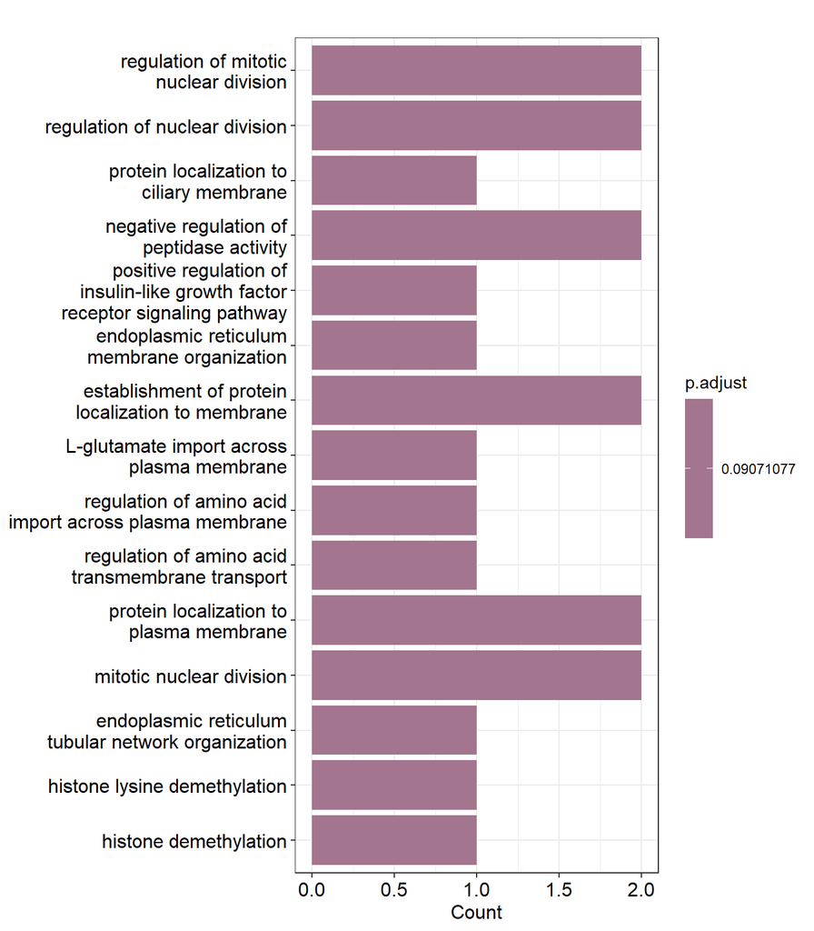

```r
barplot(egoM, showCategory=15)
```

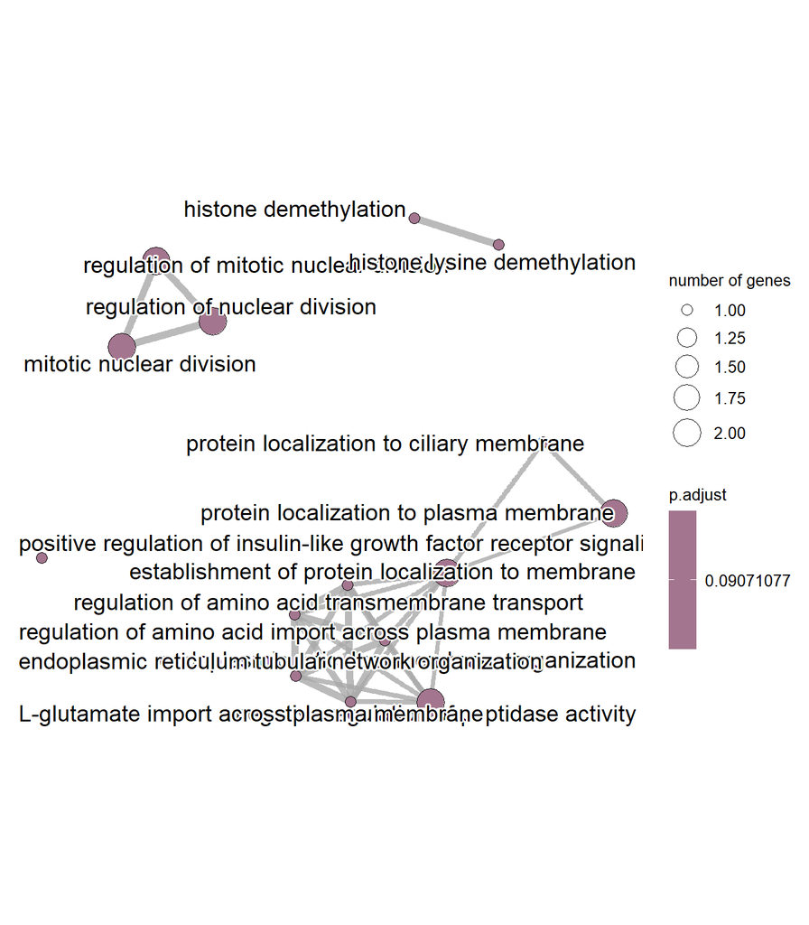

```r
y<-pairwise_termsim(egoM)
emapplot(y, showCategory = 15)
```

# DIFFERENT LIBRARIES

## GO STATS

Since results were not significant, we wanted to check if this is still the case when trying out different libraries rather than clusterProfiler.

[Tutorial](https://girke.bioinformatics.ucr.edu/GEN242/tutorials/rfea/rfea/)

```r
## Define universe and test sample set
# geneUniverse <- rownames(count.matrix)

geneUniverse <- bitr(rownames(count.matrix),
     fromType="ENSEMBL", toType="ENTREZID",
     OrgDb="org.Hs.eg.db")
geneSample <-bitr(sig_005$ensembl_gene_id,
     fromType="ENSEMBL", toType="ENTREZID",
     OrgDb="org.Hs.eg.db")
# geneUniverse <- keys(org.Hs.eg.db, keytype = "ENSEMBL")
# geneSample <- sig_005$ensembl_gene_id


## Generate params object

params <- new("GOHyperGParams",
              geneIds = geneSample,
                universeGeneIds = geneUniverse,
                annotation="org.Hs.eg", ontology = "BP", pvalueCutoff = 0.05,
                conditional = FALSE, testDirection = "over")
## Run enrichment test - Hypergeometric test
hgOver <- hyperGTest(params)
df<-summary(hgOver)

df$Adj.Pvalue <- p.adjust(df$Pvalue, 'bonferroni')

## Viewing of results
# summary(hgOver)
# htmlReport(hgOver, file = "MyhyperGresult.html") # html file will be written to current working directory
```

No significant Results could be found using GO Stats.

## KEGG

```r
kk <- enrichKEGG(gene         = geneSample$ENTREZID,
                 organism     = 'hsa',
                 pvalueCutoff = 0.05)
kk@result %>% head
```

|  | ID | Description | GeneRatio | BgRatio | pvalue | p.adjust | qvalue | geneID | Count |
| --- | --- | --- | --- | --- | --- | --- | --- | --- | --- |
| hsa04974 | hsa04974 | Protein digestion and absorption | 4/20 | 105/8842 | 7.859023e-05 | 0.003693741 | 0.003309062 | 6550/1277/1294/1292 | 4 |
| hsa04510 | hsa04510 | Focal adhesion | 3/20 | 203/8842 | 1.019023e-02 | 0.159063921 | 0.142498473 | 4660/1277/1292 | 3 |
| hsa05205 | hsa05205 | Proteoglycans in cancer | 3/20 | 204/8842 | 1.032744e-02 | 0.159063921 | 0.142498473 | 4660/1277/3481 | 3 |
| hsa04820 | hsa04820 | Cytoskeleton in muscle cells | 3/20 | 232/8842 | 1.461624e-02 | 0.159063921 | 0.142498473 | 25777/1277/1292 | 3 |
| hsa04512 | hsa04512 | ECM-receptor interaction | 2/20 | 89/8842 | 1.692169e-02 | 0.159063921 | 0.142498473 | 1277/1292 | 2 |
| hsa00604 | hsa00604 | Glycosphingolipid biosynthesis - ganglio series | 1/20 | 15/8842 | 3.342304e-02 | 0.261813821 | 0.234547656 | 2583 | 1 |

## Reactome

[Source](https://pnnl-comp-mass-spec.github.io/proteomics-data-analysis-tutorial/ora.html)

Next we tried the pathway library reactome:

```r
# RNA


universe <- bitr(rownames(count.matrix),
     fromType="ENSEMBL", toType="ENTREZID",
     OrgDb="org.Hs.eg.db")
gcUnique <-bitr(sig_005$ensembl_gene_id,
     fromType="ENSEMBL", toType="ENTREZID",
     OrgDb="org.Hs.eg.db")
react_ora <- compareCluster(
  geneClusters = gcUnique,# our significant genes
  fun = "enrichPathway", # ORA function to apply to each cluster
  organism = "human",
  pvalueCutoff = 1, # p-value filter: off
  qvalueCutoff = 1, # q-value filter: off
  pAdjustMethod = "BH", # p-values are adjusted within clusters
  universe = universe, # all genes
  minGSSize = 15,
  maxGSSize = 500
)
summary(react_ora)
```

| Cluster | ID | Description | GeneRatio | BgRatio | pvalue | p.adjust | qvalue | geneID | Count |
| --- | --- | --- | --- | --- | --- | --- | --- | --- | --- |
| ENTREZID | R-HSA-8948216 | Collagen chain trimerization | 3/28 | 44/10955 | 0.0001846339 | 0.01762626 | 0.01432475 | 1277/1294/1292 | 3 |
| ENTREZID | R-HSA-2022090 | Assembly of collagen fibrils and other multimeric structures | 3/28 | 61/10955 | 0.0004873605 | 0.01762626 | 0.01432475 | 1277/1294/1292 | 3 |
| ENTREZID | R-HSA-1442490 | Collagen degradation | 3/28 | 64/10955 | 0.0005613099 | 0.01762626 | 0.01432475 | 1277/1294/1292 | 3 |
| ENTREZID | R-HSA-1650814 | Collagen biosynthesis and modifying enzymes | 3/28 | 67/10955 | 0.0006420903 | 0.01762626 | 0.01432475 | 1277/1294/1292 | 3 |
| ENTREZID | R-HSA-2214320 | Anchoring fibril formation | 2/28 | 15/10955 | 0.0006480242 | 0.01762626 | 0.01432475 | 1277/1294 | 2 |
| ENTREZID | R-HSA-5625900 | RHO GTPases activate CIT | 2/28 | 20/10955 | 0.0011633842 | 0.02182415 | 0.01773634 | 4660/389 | 2 |
| ENTREZID | R-HSA-5627117 | RHO GTPases Activate ROCKs | 2/28 | 20/10955 | 0.0011633842 | 0.02182415 | 0.01773634 | 4660/389 | 2 |
| ENTREZID | R-HSA-216083 | Integrin cell surface interactions | 3/28 | 85/10955 | 0.0012837732 | 0.02182415 | 0.01773634 | 1277/1294/1292 | 3 |
| ENTREZID | R-HSA-1474290 | Collagen formation | 3/28 | 90/10955 | 0.0015139807 | 0.02287793 | 0.01859274 | 1277/1294/1292 | 3 |
| ENTREZID | R-HSA-5357786 | TNFR1-induced proapoptotic signaling | 2/28 | 25/10955 | 0.0018224714 | 0.02478561 | 0.02014310 | 55072/142678 | 2 |

[output cut: 126 more lines]

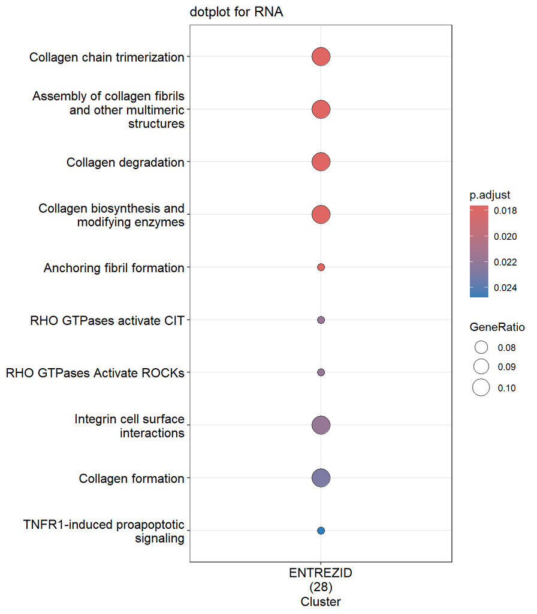

```r
rnadot<- dotplot(react_ora, showCategory=10) + ggtitle("dotplot for RNA")
rnadot
```

```r
# save plot
ggsave(plot=rnadot,
       filename = paste0(dir, "ANALYSIS/GoTermEnrichment/Plots/rnadot.png"),
       height = 5, width=9,dpi=320)
```

We get multiple significant results for collagen pathways and the gene TNRF1 is mentioned multipletimes. There is some literature on TNRF1 and endometriosis though: [TNFR1](https://www.ncbi.nlm.nih.gov/pmc/articles/PMC4287594/) The paper mentions an downregulation of TNRF1 that can be associated with early stages of endometriosis. TNRF1 was not one of our DEGs. The gene from our data involved in that pathway is RNF31, which is indeed down in our dataset but we can find no literature further linking it to endometriosis.

Collagen was another result we could indeed find [literature](https://pubmed.ncbi.nlm.nih.gov/26935598/) on. The gene in question is COL1A1. The authors found overexpression of COL1A1 in perilesional tissues (tissue around endometriosis lesions), but unfortunatly in our results COL1A1 is downregulated in patients from the diseased group compared to the control group. This might be for 2 reasons: 1) The paper mentions that COL1A1 might be upregulated in later stages of endometriosis due to its connection to scar tissue and fibrosis. That could possibly link to the downregulation found in TNFR1.

2. The tissue mentioned is perilesional tissue. Unfortunately we have no further information from our data how much tissue around the lesions was collected.

No further litereature coud be found.

Next we continue with our DMRs:

```r
universemeth <- bitr(rownames(count.meth),
     fromType="ENSEMBL", toType="ENTREZID",
     OrgDb="org.Hs.eg.db")
gcUniquemeth <-bitr(sig_DMR$ensembl_gene_id,
     fromType="ENSEMBL", toType="ENTREZID",
     OrgDb="org.Hs.eg.db")
# query
react_orameth <- compareCluster(
  geneClusters = gcUniquemeth,# our significant genes
  fun = "enrichPathway", # ORA function to apply to each cluster
  organism = "human",
  pvalueCutoff = 1, # p-value filter: off
  qvalueCutoff = 1, # q-value filter: off
  pAdjustMethod = "BH", # p-values are adjusted within clusters
  universe = universemeth, # all genes
  minGSSize = 15,
  maxGSSize = 500
)

summary(react_orameth)
```

| Cluster | ID | Description | GeneRatio | BgRatio | pvalue | p.adjust | qvalue | geneID | Count |
| --- | --- | --- | --- | --- | --- | --- | --- | --- | --- |
| ENTREZID | R-HSA-5633008 | TP53 Regulates Transcription of Cell Death Genes | 1/3 | 44/10955 | 0.01200205 | 0.03867988 | 0.005089458 | 3486 | 1 |
| ENTREZID | R-HSA-8854214 | TBC/RABGAPs | 1/3 | 46/10955 | 0.01254531 | 0.03867988 | 0.005089458 | 26088 | 1 |
| ENTREZID | R-HSA-8873719 | RAB geranylgeranylation | 1/3 | 65/10955 | 0.01769629 | 0.03867988 | 0.005089458 | 57799 | 1 |
| ENTREZID | R-HSA-8957275 | Post-translational protein phosphorylation | 1/3 | 108/10955 | 0.02928757 | 0.03867988 | 0.005089458 | 3486 | 1 |
| ENTREZID | R-HSA-977225 | Amyloid fiber formation | 1/3 | 111/10955 | 0.03009284 | 0.03867988 | 0.005089458 | 26088 | 1 |
| ENTREZID | R-HSA-9007101 | Rab regulation of trafficking | 1/3 | 124/10955 | 0.03357722 | 0.03867988 | 0.005089458 | 26088 | 1 |
| ENTREZID | R-HSA-381426 | Regulation of Insulin-like Growth Factor (IGF) transport and uptake by Insulin-like Growth Factor Binding Proteins (IGFBPs) | 1/3 | 125/10955 | 0.03384490 | 0.03867988 | 0.005089458 | 3486 | 1 |
| ENTREZID | R-HSA-3700989 | Transcriptional Regulation by TP53 | 1/3 | 362/10955 | 0.09590159 | 0.09590159 | 0.012618630 | 3486 | 1 |

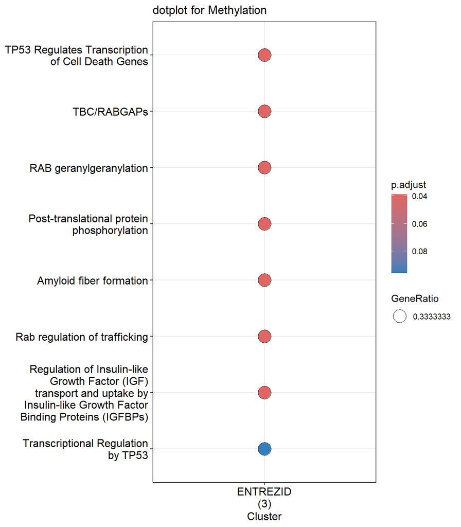

```r
methdot <- dotplot(react_orameth, showCategory=10) + ggtitle("dotplot for Methylation")
methdot
```

```r
# save plot
ggsave(plot=methdot,
       filename = paste0(dir, "ANALYSIS/GoTermEnrichment/Plots/methdot.png"),
       height = 10, width=9,dpi=320)
```

IGF is mentioned here and also pops up in other anylses and our literature research.

# Enrichr

For enrichr we used the online [database](https://maayanlab.cloud/Enrichr/) and pasted in the DEgs and DRs. No significant results for most libraries. The few significant results not relevant biologically.

# g:Profiler

Used the online [tool](https://biit.cs.ut.ee/gprofiler/gost) and pasted in the DEgs and DRs. No significant results for most libraries. The few significant results not relevant biologically.

# DOSE

[Source](https://yulab-smu.top/biomedical-knowledge-mining-book/dose-enrichment.html) Next we tried the DOSE library:

```r
doRna <- enrichDO(gene          = gcUnique$ENTREZID,
              ont           = "DO",
              pvalueCutoff  = 1,
              pAdjustMethod = "BH",
              universe      = universe$ENTREZID,
              minGSSize     = 5,
              maxGSSize     = 500,
              qvalueCutoff  = 1,
              readable      = FALSE)
head(doRna)
```

|  | ID | Description | GeneRatio | BgRatio | pvalue | p.adjust | qvalue | geneID | Count |
| --- | --- | --- | --- | --- | --- | --- | --- | --- | --- |
| DOID:13359 | DOID:13359 | Ehlers-Danlos syndrome | 3/28 | 26/9888 | 5.061972e-05 | 0.009115513 | 0.008299712 | 165/1277/84627 | 3 |
| DOID:4959 | DOID:4959 | epidermolysis bullosa dystrophica | 2/28 | 5/9888 | 7.692416e-05 | 0.009115513 | 0.008299712 | 1277/1294 | 2 |
| DOID:0080348 | DOID:0080348 | Alzheimer's disease 1 | 2/28 | 11/9888 | 4.186550e-04 | 0.028644798 | 0.026081206 | 147700/89953 | 2 |
| DOID:854 | DOID:854 | collagen disease | 3/28 | 55/9888 | 4.834565e-04 | 0.028644798 | 0.026081206 | 165/1277/84627 | 3 |
| DOID:2730 | DOID:2730 | epidermolysis bullosa | 2/28 | 25/9888 | 2.228277e-03 | 0.095185045 | 0.086666375 | 1277/1294 | 2 |
| DOID:2731 | DOID:2731 | vesiculobullous skin disease | 2/28 | 26/9888 | 2.409748e-03 | 0.095185045 | 0.086666375 | 1277/1294 | 2 |

```r
doMeth <- enrichDO(gene          = gcUniquemeth$ENTREZID,
              ont           = "DO",
              pvalueCutoff  = 1,
              pAdjustMethod = "BH",
              universe      = universemeth$ENTREZID,
              minGSSize     = 5,
              maxGSSize     = 500,
              qvalueCutoff  = 1,
              readable      = FALSE)
head(doMeth)
```

|  | ID | Description | GeneRatio | BgRatio | pvalue | p.adjust | qvalue | geneID | Count |
| --- | --- | --- | --- | --- | --- | --- | --- | --- | --- |
| DOID:1312 | DOID:1312 | focal segmental glomerulosclerosis | 2/5 | 54/9949 | 0.0002861590 | 0.03112641 | 0.01922192 | 3486/55806 | 2 |
| DOID:0050851 | DOID:0050851 | glomerulosclerosis | 2/5 | 65/9949 | 0.0004150188 | 0.03112641 | 0.01922192 | 3486/55806 | 2 |
| DOID:2449 | DOID:2449 | acromegaly | 1/5 | 5/9949 | 0.0025107952 | 0.05917637 | 0.03654400 | 3486 | 1 |
| DOID:4959 | DOID:4959 | epidermolysis bullosa dystrophica | 1/5 | 5/9949 | 0.0025107952 | 0.05917637 | 0.03654400 | 3486 | 1 |
| DOID:0080552 | DOID:0080552 | congenital disorder of glycosylation Ia | 1/5 | 6/9949 | 0.0030123485 | 0.05917637 | 0.03654400 | 3486 | 1 |
| DOID:14748 | DOID:14748 | Sotos syndrome | 1/5 | 7/9949 | 0.0035137000 | 0.05917637 | 0.03654400 | 3486 | 1 |

```r
save.image(paste0(dir, "ANALYSIS/GoTermEnrichment/goTermEnrichment.RData"))
```